# Weather Damage by Event Type

Hal Peterson

January 24, 2015

# Synopsis

We investigate the effects of 48 types of weather event, both in human terms (injuries and deaths) and monetary (crops and other economic losses). We seek to identify the most dangerous classes of weather event.

In human costs, the worst events are, in decreasing order of injuries and deaths:

1. Tornado
2. High Wind
3. Excessive Heat
4. Flood

Tornadoes are the most dangerous event to humans by a wide margin.

Monetarily, the worst events are, in decreasing order of cost:

1. High Wind
2. Tornado
3. Flash Flood
4. Flood
5. Hail
6. Lightning

# Data Processing

Acquire data, load into R, and prepare it for analysis.

- [Raw data from the Web](https://d396qusza40orc.cloudfront.net/repdata%2Fdata%2FStormData.csv.bz2): retrieved January 2015, file dated February 2014.
- [Long description of data](https://d396qusza40orc.cloudfront.net/repdata%2Fpeer2_doc%2Fpd01016005curr.pdf): retrieved January 2015, document dated August 2007.
- [FAQ on the data](https://d396qusza40orc.cloudfront.net/repdata%2Fpeer2_doc%2FNCDC%20Storm%20Events-FAQ%20Page.pdf): retrieved January 2015, document dated August 2008.

## Load data set

```r
storms <- read.csv ('StormData.csv.bz2')
```

Compute human harm as injuries plus fatalities.

```r
storms$human <- storms$FATALITIES + storms$INJURIES
human <- sum (storms$human)
```

Total human harm over all reported storms is 1.5567310^{5} people.

## Convert monetary values

Monetary damage estimates are stored in two columns, a significand and an exponent. The exponent can be numeric or a letter (e.g., ‘k’ for kilo, etc.). For analysis we must convert damage exponents to numeric values. (For the first step we ignore R warnings, because we expect them: not every EXP level is a string representing a number.)

```r
allExponents <- union (levels (storms$CROPDMGEXP),
                       levels (storms$PROPDMGEXP))
numex <- as.numeric (allExponents)
```

```r
numex[allExponents %in% c('h', 'H')] <- 2
numex[allExponents %in% c('k', 'K')] <- 3
numex[allExponents %in% c('m', 'M')] <- 6
numex[allExponents %in% c('b', 'B')] <- 9
numex[allExponents %in% c('', '?', '-', '+')] <- 0
numex <- 10 ^ numex
```

Complain if enumeration conversion missed any *EXP codes. Otherwise, display exponent values (because it doesn’t hurt).

```r
if (any (is.na (numex))) {
  print (allExponents[is.na (numex)])
  stop ('INPUT ERROR: unknown values of CROPDMGEXP and/or PROPDMGEXP')
} else {
  unique (numex)
}
```

```
##  [1] 1e+00 1e+02 1e+09 1e+03 1e+06 1e+01 1e+04 1e+05 1e+07 1e+08
```

Now we have the tools to compute monetary damage estimates.

```r
storms$money <- storms$PROPDMG * numex[storms$PROPDMGEXP] +
  storms$CROPDMG * numex[storms$CROPDMGEXP]
money <- sum (storms$money)
```

Total reported monetary damage is 1.145142910^{14}.

## Clean up event types

Categories gleaned from NOAA, plus some tools for cleaning the raw data:

```r
stormTypes <- c ('Astronomical Low Tide',
                 'Avalanche',
                 'Blizzard',
                 'Coastal Flood',
                 'Cold/Wind Chill',
                 'Debris Flow',
                 'Dense Fog',
                 'Dense Smoke',
                 'Drought',
                 'Dust Devil',
                 'Dust Storm',
                 'Excessive Heat',
                 'Extreme Cold/Wind Chill',
                 'Flash Flood',
                 'Flood',
                 'Freezing Fog',
                 'Frost/Freeze',
                 'Funnel Cloud',
                 'Hail',
                 'Heat',
                 'Heavy Rain',
                 'Heavy Snow',
                 'High Surf',
                 'High Wind',
                 'Hurricane/Typhoon',
                 'Ice Storm',
                 'Lakeshore Flood',
                 'Lake-Effect Snow',
                 'Lightning',
                 'Marine Hail',
                 'Marine High Wind',
                 'Marine Strong Wind',
                 'Marine Thunderstorm Wind',
                 'Rip Current',
                 'Seiche',
                 'Sleet',
                 'Storm Tide',
                 'Strong Wind',
                 'Thunderstorm Wind',
                 'Tornado',
                 'Tropical Depression',
                 'Tropical Storm',
                 'Tsunami',
                 'Volcanic Ash',
                 'Waterspout',
                 'Wildfire',
                 'Winter Storm',
                 'Winter Weather' )
```

Associate each official event type with a regular expression to match against actual EVTYPE values. These expressions were painstakingly based on the data, but changes to the data must make them obsolete, sooner or later.

```r
stormMatch = c ('astro.*low',
                'aval',
                'bliz',
                'coast',
                'cold|chill',
                'flow|landslide',
                'dense fog',
                'dense smoke',
                'drought',
                'dev|landspout',
                'dust.*storm',
                '(exce|record).*heat',
                'extreme cold|chill',
                'flash',
                'flood',
                '(freez|ice).* fog',
                'frost|freeze',
                'funnel',
                'hail',
                'heat',
                'rain',
                'snow',
                'surf',
                'wind',
                'typh|hurr',
                'ice storm',
                'lakeshore',
                'lake.*effect',
                'light[a-z]*ing',
                'marine hail',
                'marine high wind',
                'marine strong wind',
                'marine t.* wind',
                'rip',
                'seiche',
                'sleet',
                'storm.*tide',
                'strong',
                '(thun|tstm)',
                'torn',
                'depre',
                'trop.*storm',
                'tsu',
                'volc',
                'spout',
                'wild',
                'winter.*storm',
                'winter.*weather')
```

Pull the actual, messy values of EVTYPE from the data, and match them with official event types using the hand-crafted regular expressions defined above. The conversion tool, `toOfficial`, is an array of canonical event types, indexed by raw event type.

```r
toOfficial <- factor (levels=stormTypes)
for (evt in levels (storms$EVTYPE)) {
  toOfficial[evt] <- NA
  for (i in 1 : length (stormTypes)) {
    if (regexpr (stormMatch[i], evt, ignore.case=TRUE) >= 0) {
      toOfficial[evt] <- stormTypes[i]
      break
    }
  }
}
```

The raw event types include 262 values that do not match any of the conversion expressions. Most of these entries describe unofficial events (daily summaries, etc.). For the present analysis we ignore those events.

Now for the actual conversion: code each event in the record with its official event type.

```r
storms$official <- toOfficial[storms$EVTYPE]
```

The regular expression trick converted 99.3579719 percent of the raw events.

## Data processing summary

From the raw data we have generated three new useful variables: - `official`, the NOAA classification of each event; - `money`, the monetary cost of each event; and - `human`, the number of casualties from each event.

# Results

From the processed data we compute total costs for each official type of event.

```r
library (plyr)

humanEvents <- ddply (storms,
                      .(official),
                      summarize,
                      human=sum (human, na.rm=TRUE))

moneyEvents <- ddply (storms,
                      .(official),
                      summarize,
                      money=sum (money, na.rm=TRUE))
```

Summed this way, total casualties were 1.5567310^{5} and costs were 1.145142910^{14}.

In detail, here are casualty counts broken down by weather event type. For each event we show the total number of killed and wounded:

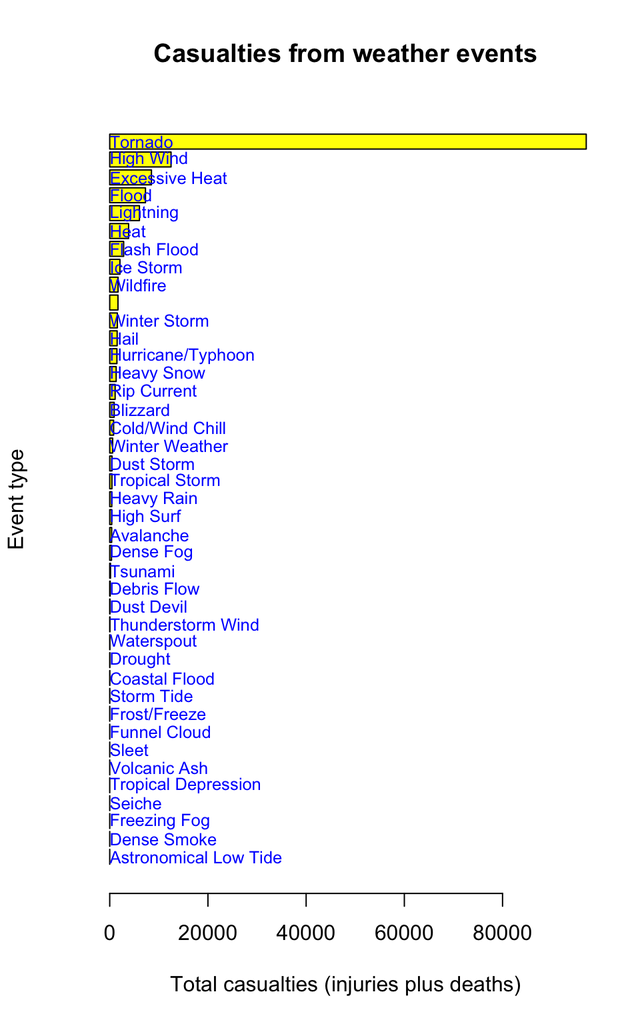

```r
humanOrder <- order (humanEvents$human)
beepy <- barplot (humanEvents$human[humanOrder],
                  horiz=TRUE,
                  col='yellow',
                  main='Casualties from weather events',
                  xlab='Total casualties (injuries plus deaths)',
                  ylab='Event type')
text (cex=0.8,
      y=beepy - 0,
      x=-1.25,
      as.character (humanEvents$official[humanOrder]),
      xpd=TRUE,
      srt=0,
      adj=0,
      col='blue')
```

```r
worst <- tail (humanOrder, 1)
```

Tornadoes are clearly the greatest weather threat to humans, accounting for 62.3377207 percent of total casualties.

For monetary costs, we show the total of crop damage and other economic harm, again by event category.

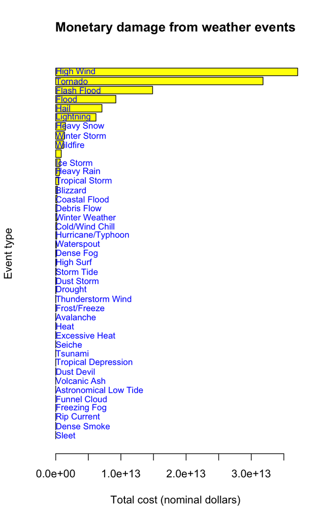

```r
moneyOrder <- order (moneyEvents$money)
beepy <- barplot (moneyEvents$money[moneyOrder],
                  horiz=TRUE,
                  col='yellow',
                  main='Monetary damage from weather events',
                  xlab='Total cost (nominal dollars)',
                  ylab='Event type')
text (cex=0.8,
      y=beepy - 0,
      x=-1.25,
      as.character (moneyEvents$official[moneyOrder]),
      xpd=TRUE,
      srt=0,
      adj=0,
      col='blue')
```

```r
worst <- tail (moneyOrder, 6)
```

Monetary damages are less tightly distributed than casualties, but still the top 6 most destructive event types account for 92.8181058 percent of total costs.